# Mise en production ARMA

Ce notebook est un test pour la mise en production de la gÃ©nÃ©ration d'une sÃ©rie process AR.

Le modÃ¨le AR a plusieurs paramÃ¨tres a determiner. Nous nous limitons ÃÂ la modification des paramÃ¨tres suivants:

- mu
- rho

## Parametrage

Pour mettre en production le notebook, nous avons besoin d'avoir les librarie suivantes installÃ©es:

- papermil : https://github.com/nteract/papermill/
- jupytext : https://github.com/mwouts/jupytext
- https://medium.com/capital-fund-management/automated-reports-with-jupyter-notebooks-using-jupytext-and-papermill-619e60c37330

Il est possible de configurer un fichier requirement:

```
# Notebook dependencies

# Tools used in the article
jupytext>=1.2
papermill>=1.2
nbconvert>=5.5
jupyter_core>=4.5

# TOC extension for Binder
jupyter_contrib_nbextensions
```

Il faut parametrer le notebook avec Jupytext afin de gÃ©nÃ©rerer automatiquement les markdowns dans une optique de versioning

## Ligne de commande

Pour utiliser en production le notebook, il suffit d'utiliser la ligne de commande suivante

```
type test_notebook.md | \
 jupytext --from md --to ipynb --set-kernel - | \
  papermill -p p 0.5 -p mu 0.5 -p start_date 1/1/2019 | \
   jupyter nbconvert --stdin --output test_notebook.html
```

Sinon lancer le fichier python `auto.py`. Le fichier genÃ¨re automatiquement un dS et utilise la date du jour pour la date de valuation.

```python
import ARMA
import pandas as pd
```

## Parametre AR

Pour gÃ©nÃ©rer une time serie avec un processus AR d'ordre un, il faut renseigner le mu et le rho. Il faut aussi renseigner la date de dÃ©but. On va gÃ©nÃ©rer par defaut 500 dates

Il faut changer

- `p`
- `mu`
- `start_date`

A noter que la cellule ci dessous est une cellule par defaut. Papermill gÃ©nÃ©rer une nouvelle cellule en dessus avec les nouvelles valeurs.

```python
p = 0.8
mu = 0.8
start_date = '1/1/2019'
```

```python
# Parameters
p = 0.365
mu = 0.257
start_date = "04/11/2019"
```

```python
start_date = "1/1/2020"
```

```python
AR = ARMA.AR(p = p, mu= mu, lenght = 500)
```

```python
date_ = pd.date_range(start=start_date, periods=500)
date_
```

```
DatetimeIndex(['2020-01-01', '2020-01-02', '2020-01-03', '2020-01-04',
               '2020-01-05', '2020-01-06', '2020-01-07', '2020-01-08',
               '2020-01-09', '2020-01-10',
               ...
               '2021-05-05', '2021-05-06', '2021-05-07', '2021-05-08',
               '2021-05-09', '2021-05-10', '2021-05-11', '2021-05-12',
               '2021-05-13', '2021-05-14'],
              dtype='datetime64[ns]', length=500, freq='D')
```

```python
df_ar = pd.DataFrame(AR, index =date_)
df_ar.head()
```

|  | y | x |
| --- | --- | --- |
| 2020-01-01 | -1.656531 | 0.00000 |
| 2020-01-02 | 0.465881 | 0.02004 |
| 2020-01-03 | 0.656378 | 0.04008 |
| 2020-01-04 | -0.372887 | 0.06012 |
| 2020-01-05 | 1.556521 | 0.08016 |

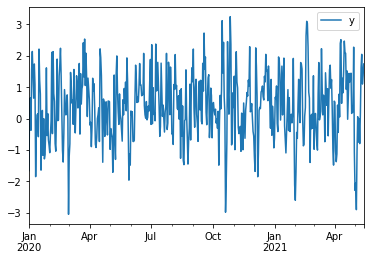

```python
df_ar.plot.line(y = 'y')
```

## Statistique

```python
import seaborn as sns

cm = sns.light_palette("green", as_cmap=True)
```

```python
df_ar.assign(month = lambda x:x.index.month,
            year = lambda x:x.index.year).groupby('month').agg({
    'y':['min','max', 'mean']
}).style.background_gradient(cmap=cm)
```

| month | y min | y max | y mean |
| --- | --- | --- | --- |
| 1 | -2.11148 | 2.21174 | 0.221164 |
| 2 | -3.04717 | 3.09467 | 0.338603 |
| 3 | -1.48065 | 2.53056 | 0.603447 |
| 4 | -1.391 | 2.511 | 0.491161 |
| 5 | -2.89938 | 2.04439 | -0.027332 |
| 6 | -0.730349 | 2.07437 | 0.591327 |
| 7 | -0.566624 | 2.37127 | 0.667184 |
| 8 | -1.46769 | 2.03742 | 0.150473 |
| 9 | -0.72583 | 2.72126 | 0.700157 |
| 10 | -2.98048 | 3.24333 | 0.443707 |
| 11 | -1.04257 | 2.28681 | 0.352481 |
| 12 | -1.85195 | 2.24916 | 0.461731 |